# Cyclistic Programme Monitor

Chicago Divvy · 2021–2025

## Members commute; casual riders leisure-ride.

Of 27.7 million cleaned trips, casual riders take 39% and members 61%. Weekend share 38% vs 24%; median 13.5 vs 9.1 min. **2.0 million casual trips** are already short weekday peak-hour rides — the conversion target.

Trip-level only: Divvy files have no rider id.

Casual

10.8 million trips

38.8% of all trips · 38% weekend · 13.5 min median

Member

17.0 million trips

61.2% of all trips · 24% weekend · 9.1 min median

Conversion pool

2.0 million casual trips

18.6% of casual riding · weekday peak, under 15 min

Members peak twice on weekdays; casual riders peak once in the afternoon

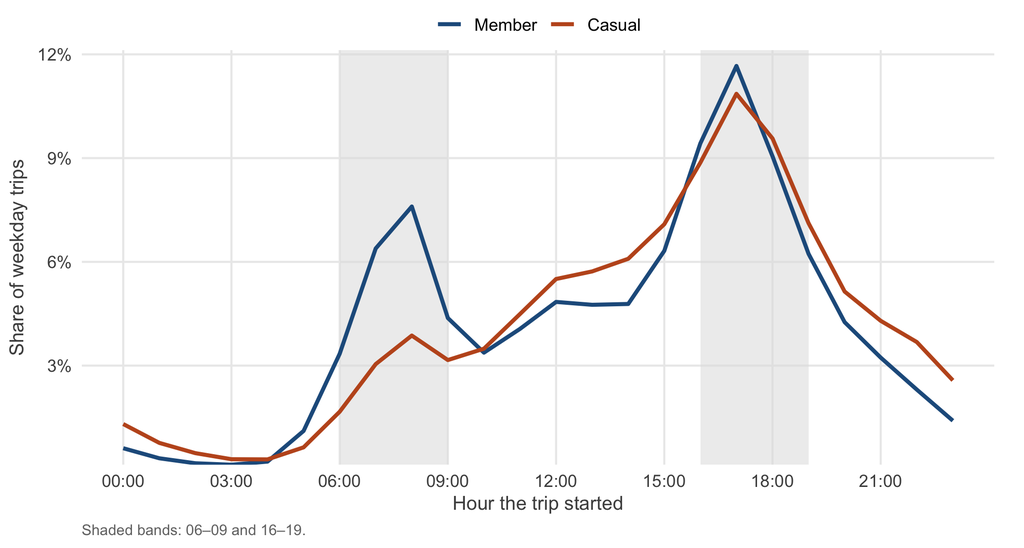

Casual riding is weekend and long; member riding is weekday and short

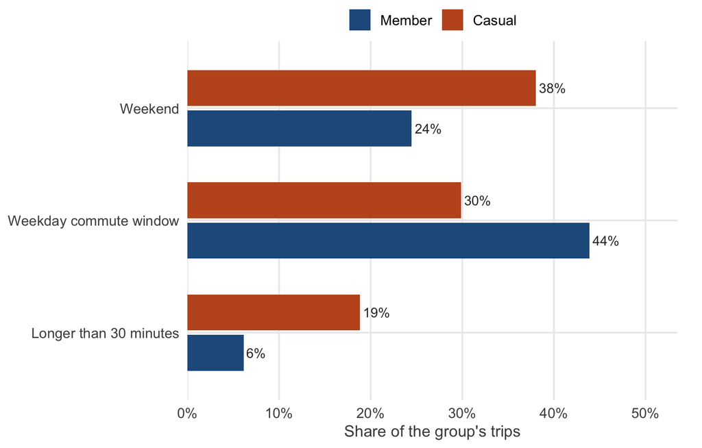

Commute-like casual trips show up in summer, not winter

[figure not shown]

Member trips bunch under 15 minutes; casual trips have a long tail

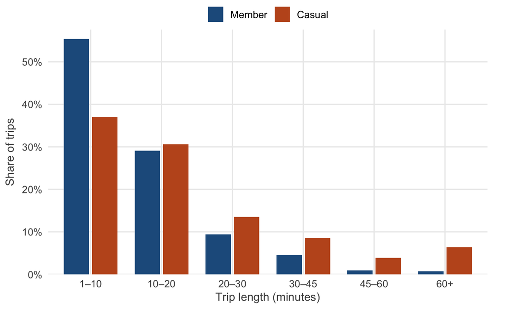

Members concentrate on weekday evenings; casual riders spread into weekends

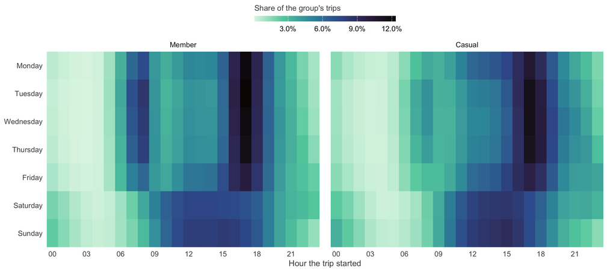

Casual riders pile into summer; members ride all year

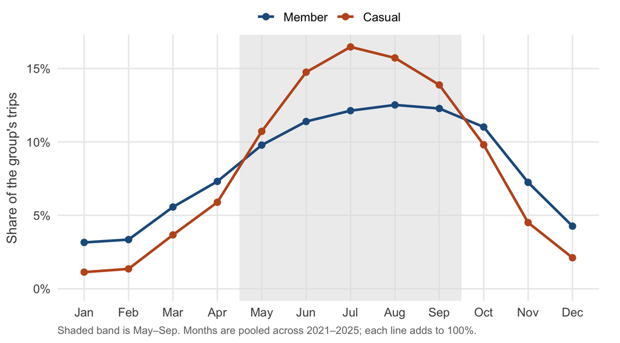

Winter trips are mostly members; summer trips split more evenly

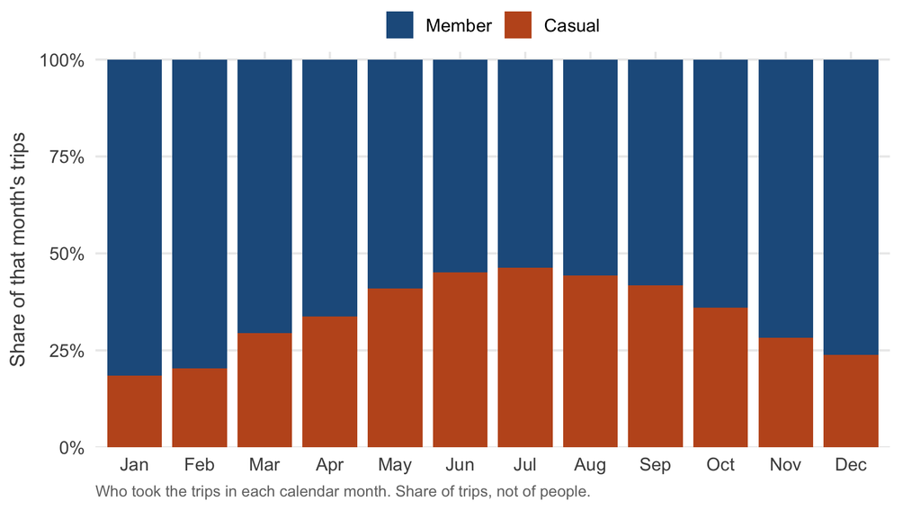

Bike type does not separate the two groups

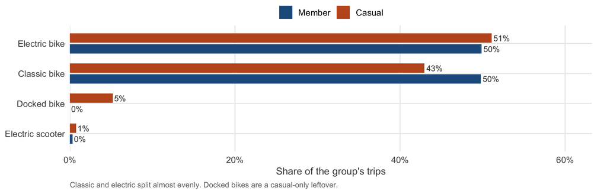

2.3% of source records were excluded against a documented reason

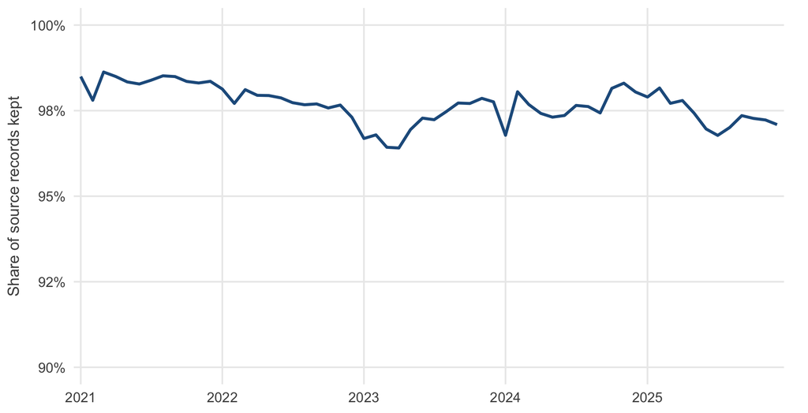

Sub-minute rides (dock glitches) account for most exclusions

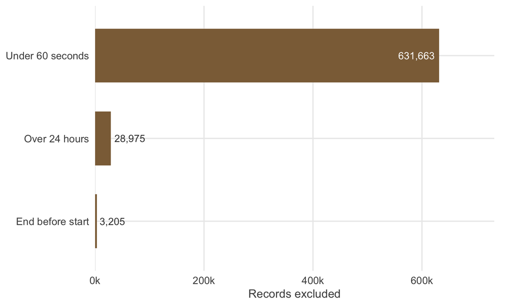

**Answered here.** How member and casual *trips* differ in timing, length, day of week, season and bike choice, across 60 months and 27,732,376 cleaned trips.

**Not answerable from this data.** Anything about *people*. Divvy’s public files carry no rider identifier, so a rider taking 200 trips and 200 riders taking one trip each are indistinguishable. Every figure here is a share of trips, never a share of riders, and no conversion rate or per-rider frequency can be derived.

**Statistical note.** The member/casual difference in weekend riding is overwhelmingly significant on a chi-square test, but that test assumes independent observations and trips cluster within unobserved riders. The p-value is reported in the repository as descriptive only; the effect sizes on the first page are the meaningful result.

Full indicator definitions, exclusion rules and pipeline architecture are in METHODS.md.